# COMP529 Big Data Analytics: CA2 (PCA Assignment)

LIZIHE 201820778

# Important — Read This First

- Open this file in **RStudio**.
- Switch to **Visual Mode** (button at the top-left of the editor).
- Complete all R code chunks marked with `# YOUR CODE GOES HERE`.
- If you are given a hint, try using RStudio’s Help feature for the given keyword - e.g. for ‘plot’, type  
  **?plot**  
  into the console and you will see useful help information appear in the Help pane.
- Write your explanations in the **Explanation boxes** below each question.
  - Do **not delete** the line starting with `# Qx_EXPLANATION` — it helps us identify your answers.
- When finished, click **Knit → HTML** to output your answers.
- Submit **both the HTML file and the Rmd file** via Canvas.

In this assignment you will clean financial time-series data, build a consistent panel of daily closing prices, compute daily returns, and apply Principal Component Analysis (PCA) to study how market-wide factors explain variation in stock movements. Each question builds step-by-step toward the PCA analysis.

# Environment Setup

```r
# Required packages
# Uncomment to install any that are missing:
# install.packages(c("tidyverse", "lubridate", "inflection"))

library(tidyverse)
library(lubridate)
library(inflection)
```

# Helper Functions

```r
# Elbow finder function (distance-from-line method)
find_elbow <- function(x, y) {
  x <- (x - min(x)) / (max(x) - min(x))
  y <- (y - min(y)) / (max(y) - min(y))
  y_smooth <- stats::filter(y, rep(1/3, 3), sides = 2)
  y_smooth[is.na(y_smooth)] <- y[is.na(y_smooth)]
  p1 <- c(x[1], y_smooth[1])
  p2 <- c(x[length(x)], y_smooth[length(y_smooth)])
  dist <- abs((p2[2] - p1[2]) * x - (p2[1] - p1[1]) * y_smooth +
              p2[1]*p1[2] - p2[2]*p1[1]) /
          sqrt((p2[2] - p1[2])^2 + (p2[1] - p1[1])^2)
  bias <- seq_along(dist)
  dist_adj <- dist / sqrt(bias)
  which.max(dist_adj)
}
```

## Q1 : Load data

**Tasks:**  
Unzip `stock_data.zip`, which contains historical market data for stocks in the S&P 500 index.  
The S&P 500 is a stock market index tracking the performance of 500 large companies listed on stock exchanges in the United States.  
(a) Load the data from the CSV file into an R data frame. It should have 7 columns:  
`Date`: the date for a given set of observations  
`Open`: the price of a given stock on a given date, at opening time on the relevant stock exchange  
`High`: the highest price reached by a given stock on a given date  
`Low`: the lowest price reached by a given stock on a given date  
`Close`: the price of a given stock on a given date, at closing time on the relevant stock exchange  
`Volume`: the total volume traded for a given stock on a given date  
`Name`: The stock name  
This assignment will use the `Date`, `Close`, and `Name` columns.  
(b) Use `glimpse` to display a preview of the data.  
**Hint:** the `readr` package is useful when loading data from files.  
Ensure that the file path provided is correct relative to the current working directory. If you’re unsure, check your working directory in the console using `getwd()`.  
There is no code explanation needed for Q1.

```r
# YOUR CODE GOES HERE
stock_data <- readr::read_csv("stock_data.zip")
dplyr::glimpse(stock_data)
```

```
## Rows: 622,018
## Columns: 7
## $ Date   <date> 2019-07-02, 2019-07-03, 2019-07-05, 2019-07-08, 2019-07-09, 20…
## $ Open   <dbl> 73.009, 74.158, 73.144, 71.300, 70.923, 70.846, 69.272, 69.185,…
## $ High   <dbl> 75.61, 76.80, 75.75, 73.84, 73.45, 73.37, 71.74, 71.65, 70.55, …
## $ Low    <dbl> 76.18, 76.93, 76.47, 75.99, 74.08, 73.94, 73.78, 72.27, 71.02, …
## $ Close  <dbl> 75.25, 75.70, 75.30, 73.50, 73.11, 73.13, 71.48, 70.83, 69.49, …
## $ Volume <dbl> 1877000, 1153100, 1493100, 2217400, 2092200, 1785200, 6562400, …
## $ Name   <chr> "A", "A", "A", "A", "A", "A", "A", "A", "A", "A", "A", "A", "A"…
```

## Q2 : Distinct tickers

**Tasks:**  
(a) Identify the set of all unique tickers (from the `Name` column), sorted alphabetically.  
(b) How many tickers are there?  
(c) List the first 5 tickers.  
(d) List the last 5 tickers.

**Hints:**  
`distinct()`, `arrange()`, and `pull()` may help with part (a).  
Functions like `length()`, `head()`, and `tail()` will help with parts (b), (c), and (d).

```r
# YOUR CODE GOES HERE
tickers <- stock_data %>%
  distinct(Name) %>%
  arrange(Name) %>%
  pull(Name)

number_tickers <- length(tickers)
print(paste("Number:", number_tickers))
```

```
## [1] "Number: 500"
```

```r
first_5 <- head(tickers, 5)
print(first_5)
```

```
## [1] "A"    "AAPL" "ABBV" "ABNB" "ABT"
```

```r
last_5 <- tail(tickers, 5)
print(last_5)
```

```
## [1] "XYL"  "YUM"  "ZBH"  "ZBRA" "ZTS"
```

**Explanation box (do not delete this section):**

```
# Q2_EXPLANATION
Explain your code here.
`distanct()` filters targets by their names. `arrange()` sorts targets alphabetically. `pull()` converts the target into a vector. `length()` calculates the length (and counts the number of elements). `head()` retrieves the data from the beginning of the string. `tail()` retrieves the data from the end of the string.
```

## Q3 : Filter tickers by coverage

**Tasks:**  
(a) Remove all tickers whose first available date is after 1st November 2019 or whose last available date is before 31st October 2022.  
(b) Which tickers were removed? (Display the ticker names.)  
(c) How many tickers remain?  
**Hints:** You might want to group the data by `Name` using `group_by()`. Then, consider calculating each ticker’s first and last date with `summarise(min(Date), max(Date))`. You could use `filter()` to compare these dates with the required window. To identify which tickers were kept vs removed, `setdiff()` might be helpful.  
After filtering out the above names, you should be left with all of the names which have market data for at least the 3 years period 1st November 2019 – 31st October 2022. You should have removed a small number of names: these are stocks which **started trading after 1st November 2019** or **ceased trading before 31st October 2022**. You should be left with close to 500 names. Use these 500-ish names for the rest of the assignment. The names you removed will not be used again, because they don’t have sufficient market data.

```r
# YOUR CODE GOES HERE
ticker_dates <- stock_data %>%
  group_by(Name) %>%
  summarise(
    first_date = min(Date),
    last_date = max(Date)
  )

available_tickers <- ticker_dates %>%
  filter(first_date <= as.Date("2019-11-01") & last_date >= as.Date("2022-10-31")) %>%
  pull(Name)

filtered_date <- stock_data %>%
  filter(Name %in% available_tickers)

all_tickers <- unique(stock_data$Name)
removed_tickers <- setdiff(all_tickers, available_tickers)

print(removed_tickers)
```

```
##  [1] "ABNB" "CARR" "CEG"  "GEHC" "GEV"  "KVUE" "OTIS" "PLTR" "SOLV" "VLTO"
```

```r
number_remaining <- length(available_tickers)
print(paste(number_remaining))
```

```
## [1] "490"
```

**Explanation box (do not delete this section):**

```
# Q3_EXPLANATION
Explain your code here.
First, create "ticker_dates" to calculate the earliest and latest dates for each stock.

Second, create "available_tickers" for filtering.

Third, create "filtered_data" to filter and store the data from the original dataset.

`setdiff()` identifies the removed stocks by comparing the differences between two sets.
```

## Q4 : Common trading dates

**Tasks:**  
(a) Identify the set of dates that are common to all remaining tickers.  
(b) Remove all the dates that are before **1st November 2019 or after 31st October 2022.**

By identifying common dates, we ensure that every stock has data for the same set of days, which is crucial for performing comparisons, statistical analysis, or any kind of multivariate analysis later.  
(c) How many dates are left?  
(d) List the first 5 dates  
(e) List the last 5 dates.  
**Hints:** `filter()` could be used here. For each date, count how many *distinct* tickers appear using `n_distinct(Name)`.  
A “common” date is one where the count equals the number of remaining tickers.  
There are approximately 250 trading days in a year, and the period 1st November 2019 to 31st October 2022 spans 3 years. So, you should be left with approximately 250 * 3 = 750 dates. The first 5 dates should be close to (but not before) 1st November 2019. The last 5 dates should be close to (but not after) 31st October 2022.

```r
# YOUR CODE GOES HERE
date_counts <- filtered_date %>%
  group_by(Date) %>%
  summarise(ticker_count = n_distinct(Name))

common_dates <- date_counts %>%
  filter(ticker_count == number_remaining) %>%
  pull(Date)

final_dates <- common_dates %>%
  as.Date() %>%
  .[. >= as.Date("2019-11-01") & .<= as.Date("2022-10-31")] %>%
  sort()

number_dates <- length(final_dates)
print(paste("Number of common trading dates:", number_dates))
```

```
## [1] "Number of common trading dates: 755"
```

```r
first_5_dates <- head(final_dates,5)
print("first 5 common trading dates:")
```

```
## [1] "first 5 common trading dates:"
```

```r
print(first_5_dates)
```

```
## [1] "2019-11-01" "2019-11-04" "2019-11-05" "2019-11-06" "2019-11-07"
```

```r
last_5_dates <- tail(final_dates,5)
print("last 5 common trading dates:")
```

```
## [1] "last 5 common trading dates:"
```

```r
print(last_5_dates)
```

```
## [1] "2022-10-25" "2022-10-26" "2022-10-27" "2022-10-28" "2022-10-31"
```

**Explanation box (do not delete this section):**

```
# Q4_EXPLANATION
Explain your code here.
`date_counts` groups by date and counts the number of stocks traded on each trading day.

`n_distinct()` calculates how many distinct stocks have trading data for each date.

`common_dates` filters for dates where all remaining stocks have trading data.

`ticker_count == number_remaining` ensures that all stocks have trading records on a given day.

`pull(Date)` extracts the date column as a vector.
```

## Q5 : Build wide close-price data frame

**Tasks:**  
(a) Build a new wide data frame (aka *tibble*) that has a column for each of the tickers from Q3 and a row for each of the dates from Q4. The data frame should contain the `Close` values for each corresponding ticker and date.  
(b) Print the resulting data frame.  
**Hint:** `pivot_wider()` is useful here.  
Make sure you include only the **common dates** from Q4, otherwise you will see `NA`s.

```r
# YOUR CODE GOES HERE
close_wide <- filtered_date %>%
  filter(Date %in% final_dates) %>%
  select(Date,Name,Close) %>%
  pivot_wider(
    names_from = Name,
    values_from = Close
  )
print(close_wide)
```

```
## # A tibble: 755 × 491
##    Date           A  AAPL  ABBV   ABT  ACGL   ACN  ADBE   ADI   ADM   ADP  ADSK
##    <date>     <dbl> <dbl> <dbl> <dbl> <dbl> <dbl> <dbl> <dbl> <dbl> <dbl> <dbl>
##  1 2019-11-01  76.3  62.3  79.1  82.6  41.4  186.  277.  108.  42.0  162.  148.
##  2 2019-11-04  76.7  63.8  82.1  82.2  40.8  187.  276.  110.  42.5  162.  150.
##  3 2019-11-05  75.5  64.1  81.5  80.9  40.2  185.  284.  111.  42.9  157.  149.
##  4 2019-11-06  74.9  63.8  80.4  82.4  40.6  187.  286.  111.  42.8  157.  150.
##  5 2019-11-07  75.7  64.5  81.1  82.9  40.4  189.  287   112.  43.1  160.  151
##  6 2019-11-08  75.6  64.2  82.1  83.2  40.3  188.  288.  111.  42.9  161.  150.
##  7 2019-11-11  76.1  64.6  83.9  83.3  40.4  189.  290.  111.  43.0  162.  152.
##  8 2019-11-12  76.7  65.2  85.6  83.7  40.2  190.  290.  113.  43.0  164.  154.
##  9 2019-11-13  76.6  65.3  85.3  83.3  40.1  190.  290.  112.  42.7  166.  156.
## 10 2019-11-14  76.5  65.5  85.9  83.7  40.5  194.  292.  113.  42.6  168.  157.
## # ℹ 745 more rows
## # ℹ 479 more variables: AEE <dbl>, AEP <dbl>, AES <dbl>, AFL <dbl>, AIG <dbl>,
## #   AIZ <dbl>, AJG <dbl>, AKAM <dbl>, ALB <dbl>, ALGN <dbl>, ALL <dbl>,
## #   ALLE <dbl>, AMAT <dbl>, AMCR <dbl>, AMD <dbl>, AME <dbl>, AMGN <dbl>,
## #   AMP <dbl>, AMT <dbl>, AMZN <dbl>, ANET <dbl>, ANSS <dbl>, AON <dbl>,
## #   AOS <dbl>, APA <dbl>, APD <dbl>, APH <dbl>, APTV <dbl>, ARE <dbl>,
## #   ATO <dbl>, AVB <dbl>, AVGO <dbl>, AVY <dbl>, AWK <dbl>, AXON <dbl>, …
```

**Explanation box (do not delete this section):**

```
# Q5_EXPLANATION
Explain your code here.
Data Filtering:
`filter(Date %in% final_dates)`: Retains only the common trading days determined in Q4.
`select(Date, Name, Close)`: Retains only the date, stock name, and closing price columns.

Convert to Wide Format:
`pivot_wider()`: Converts data from long format to wide format.
`names_from = Name`: Uses the stock name as the column name for the new column.
`values_from = Close`: Uses the closing price as the value for the new column.
```

## Q6 : Calculate returns

**Tasks:**  
(a) Create another data frame/tibble containing daily simple returns calculated as:  
`return(Name, Date) = (Close(Name, Date) - Close(Name, previous Date)) / Close(Name, previous Date)`  
Note that this dataframe should have one fewer row than the data frame from Q5, because returns can’t be calculated for the first date.  
(b) Output the data frame with `print()`.  
**Hints:** `lag()` accesses the previous row’s closing price, also consider `across()` to apply the calculation to all columns except the Date.  
Remember: `return = (price_t - price_{t-1}) / price_{t-1}`  
The first row of returns will be `NA` for every stock. `slice()` may be useful.

```r
# YOUR CODE GOES HERE
simple_returns <- close_wide %>%
  arrange(Date) %>%
  mutate(across(-Date, ~(.)/ lag(.)-1))%>%
  slice(-1)
print(simple_returns)
```

```
## # A tibble: 754 × 491
##    Date               A      AAPL     ABBV      ABT      ACGL      ACN      ADBE
##    <date>         <dbl>     <dbl>    <dbl>    <dbl>     <dbl>    <dbl>     <dbl>
##  1 2019-11-04  0.00537   0.0250    0.0380  -0.00472 -0.0121    0.00688  -4.40e-3
##  2 2019-11-05 -0.0164    0.00368  -0.00816 -0.0161  -0.0152   -0.0102    2.74e-2
##  3 2019-11-06 -0.00702  -0.00371  -0.0137   0.0183   0.00994   0.00771   7.09e-3
##  4 2019-11-07  0.00987   0.0107    0.00909  0.00643 -0.00517   0.00942   4.87e-3
##  5 2019-11-08 -0.000396 -0.00487   0.0125   0.00326 -0.00272  -0.00212   5.16e-3
##  6 2019-11-11  0.00635   0.00556   0.0220   0.00156  0.00174   0.00149   4.23e-3
##  7 2019-11-12  0.00775   0.0102    0.0197   0.00420 -0.00545   0.00700   1.97e-3
##  8 2019-11-13 -0.00209   0.000583 -0.00257 -0.00466 -0.000996  0.00327  -3.45e-5
##  9 2019-11-14 -0.00104   0.00394   0.00703  0.00492  0.00847   0.0175    6.51e-3
## 10 2019-11-15  0.00170   0.00348   0.0155   0.00860 -0.00198   0.0102    4.83e-3
## # ℹ 744 more rows
## # ℹ 483 more variables: ADI <dbl>, ADM <dbl>, ADP <dbl>, ADSK <dbl>, AEE <dbl>,
## #   AEP <dbl>, AES <dbl>, AFL <dbl>, AIG <dbl>, AIZ <dbl>, AJG <dbl>,
## #   AKAM <dbl>, ALB <dbl>, ALGN <dbl>, ALL <dbl>, ALLE <dbl>, AMAT <dbl>,
## #   AMCR <dbl>, AMD <dbl>, AME <dbl>, AMGN <dbl>, AMP <dbl>, AMT <dbl>,
## #   AMZN <dbl>, ANET <dbl>, ANSS <dbl>, AON <dbl>, AOS <dbl>, APA <dbl>,
## #   APD <dbl>, APH <dbl>, APTV <dbl>, ARE <dbl>, ATO <dbl>, AVB <dbl>, …
```

**Explanation box (do not delete this section):**

```
# Q6_EXPLANATION
Explain your code here.
`arrange(Date)`: Sorts data by date, which is beneficial for calculations.

`mutate(across(-Date, ~ (.) / lag(.) - 1))`:

`across(-Date)`: Applyes the same calculation to all columns except the date column.
`~ (.) / lag(.) - 1`: The formula for calculating simple returns.
`(.)` represents the value of the current row.
`lag(.)` represents the value of the previous row (lagging by one period).
`slice(-1)`: Deletes the first row because it contains no data from the previous day for calculating returns, so all values are NA.

However, the output is difficult to read.
```

## Q7 : PCA on returns

**Tasks:**  
(a) Use the function `prcomp()` to calculate the principal components of the returns from Q6.  
The PCA loadings show how each ticker contributes to each principal component. Large positive or negative loadings indicate strong influence on that component. PCA helps reveal the main underlying factors that explain variance in stock returns, and is commonly used in finance to identify shared trends across assets.  
(b) Print the loadings for the top five principal components. The loadings are stored in the `$rotation` matrix of the PCA result (use whatever variable name you assigned the `prcomp()` output to).  
**Hints:** Remember to remove the Date column and convert the remaining columns to a matrix using `as.matrix()` before running `prcomp()`.  
You could use `order()` to find the top components.

```r
# YOUR CODE GOES HERE
returns_matrix <- simple_returns %>%
  select(-Date) %>%
  as.matrix()

result <- prcomp(returns_matrix)
loadings <- result$rotation

print(loadings[, 1:5])
```

```
##                 PC1           PC2           PC3           PC4           PC5
## A     -3.053307e-02 -5.702523e-02  0.0042818532 -0.0256461997  0.0175122915
## AAPL  -3.228756e-02 -6.911258e-02 -0.0059995856 -0.0320441061  0.0269037453
## ABBV  -2.491468e-02 -1.543889e-02  0.0249501799 -0.0071804557 -0.0516810148
## ABT   -2.167720e-02 -6.232393e-02  0.0426635797 -0.0130923670  0.0002328845
## ACGL  -4.393011e-02  1.263271e-02  0.0641793512  0.0311088528  0.0192290205
## ACN   -3.901690e-02 -4.439813e-02  0.0175454277 -0.0064438312 -0.0021444701
## ADBE  -3.349713e-02 -8.190256e-02 -0.0530295996 -0.0342329307 -0.0199294290
## ADI   -4.014121e-02 -3.418958e-02 -0.0305451459 -0.0176348322  0.0424036801
## ADM   -3.220724e-02  1.569988e-02  0.0493970426 -0.0306080485  0.0050417238
## ADP   -3.546516e-02 -2.348083e-02  0.0230706181  0.0167632740 -0.0373421534
## ADSK  -4.510164e-02 -6.407046e-02 -0.0524350274 -0.0246320952  0.0049894016
## AEE   -2.102387e-02 -3.484489e-02  0.0861510001  0.0114069583 -0.0162478098
## AEP   -2.223525e-02 -2.970992e-02  0.0852715444  0.0150041994 -0.0338071832
## AES   -5.299079e-02  1.248115e-02 -0.0319701664  0.0135114488 -0.0677988711
## AFL   -4.981519e-02  2.992744e-02  0.0258700597  0.0315838883 -0.0227163178
## AIG   -7.015992e-02  5.769533e-02  0.0131510848  0.0261336674 -0.0125916131
## AIZ   -3.547961e-02  1.589583e-02  0.0256236618  0.0069016922 -0.0061632675
## AJG   -3.780824e-02 -1.988804e-02  0.0226237155  0.0108808413 -0.0484788904
## AKAM  -1.866404e-02 -6.179706e-02  0.0169814388 -0.0390449028 -0.0043767104
## ALB   -5.824878e-02 -1.558582e-02  0.0134554115 -0.0585197042  0.1248071503
## ALGN  -5.762517e-02 -5.294259e-02 -0.0529918259  0.0101487895  0.0236168705
## ALL   -3.962675e-02  5.988275e-03  0.0376084401  0.0095661020 -0.0808053808
## ALLE  -4.315445e-02 -1.697629e-02  0.0448727269  0.0120655604 -0.0114055494
## AMAT  -5.361159e-02 -5.478883e-02 -0.0479942912 -0.0305772987  0.0742302089
## AMCR  -3.725294e-02 -4.415682e-03  0.0213208124  0.0126475616 -0.0150607936
## AMD   -4.484599e-02 -9.723134e-02 -0.0734558554 -0.0620533885  0.0491578699
## AME   -4.553452e-02 -1.219223e-02  0.0189778402 -0.0010278186 -0.0192679224
## AMGN  -1.609566e-02 -3.251517e-02  0.0448682469 -0.0188025046 -0.0082107932
## AMP   -5.806429e-02  8.222072e-03  0.0300154661  0.0070929105  0.0529056814
## AMT   -2.622516e-02 -5.876883e-02  0.0585436003  0.0023015744 -0.0325380597
## AMZN  -2.689656e-02 -7.853793e-02 -0.0372015400 -0.0459514187  0.0335307999
## ANET  -3.845238e-02 -5.499814e-02 -0.0081523341 -0.0316922826  0.0457411270
## ANSS  -3.428707e-02 -8.209547e-02 -0.0182307007 -0.0338498990  0.0334799307
## AON   -3.272284e-02 -1.772046e-02  0.0229621403 -0.0113912399 -0.0275874257
## AOS   -3.105063e-02 -1.372518e-02  0.0220992271  0.0215016375  0.0326472523
## APA   -9.346660e-02  1.429814e-01 -0.0247296639 -0.2252297531 -0.0306984053
## APD   -3.328748e-02 -2.663150e-02  0.0416713309 -0.0065529467  0.0165330495
## APH   -4.282063e-02 -2.284662e-02 -0.0026840124 -0.0000540608  0.0153329621
## APTV  -7.592295e-02  2.259762e-02 -0.1098799676  0.0472186356 -0.0537170006
```

[output cut: 436 more lines]

```
## WM    -2.573352e-02 -3.059689e-02  0.0643675194 -0.0080214373 -0.0291093864
## WMB   -5.093589e-02  6.817568e-02 -0.0346333768 -0.0714997859 -0.1092172298
## WMT   -1.079734e-02 -3.519340e-02  0.0343604562 -0.0218628866  0.0044455469
## WRB   -3.562472e-02  1.035507e-02  0.0622900538  0.0158628028  0.0101215320
## WST   -2.319872e-02 -8.073703e-02 -0.0058234421 -0.0327566808 -0.0098655230
## WTW   -3.328634e-02 -1.864696e-02  0.0211244560  0.0092462451 -0.0264401375
## WY    -5.167566e-02 -8.149615e-03  0.0410034503  0.0167746682  0.0307097141
## WYNN  -8.067032e-02  6.204118e-02 -0.1276425098  0.0626095134  0.0243989759
## XEL   -1.997546e-02 -3.627208e-02  0.0729015652  0.0164454433 -0.0338565350
## XOM   -4.544646e-02  6.301585e-02  0.0368485638 -0.0964385445 -0.0014495797
## XYL   -4.250339e-02 -1.934389e-02  0.0342491134  0.0146324953  0.0399575773
## YUM   -3.604608e-02 -1.450466e-02  0.0051434825  0.0353733621 -0.0092280685
## ZBH   -4.591686e-02 -7.161699e-04  0.0022564153  0.0235543946 -0.0250465181
## ZBRA  -4.311538e-02 -4.360575e-02  0.0001356187 -0.0228519675  0.0494970006
## ZTS   -3.219470e-02 -5.302061e-02  0.0078204241  0.0035113316 -0.0411610121
```

**Explanation box (do not delete this section):**

```
# Q7_EXPLANATION
Write your explanation here.
`select(-Date)`: Removes the date column because PCA loading does not require dates.
`as.matrix()`: Converts the data frame to matrix format, as this is required by the `prcomp()` function.

Perform PCA:
`prcomp(Returns_Matrix)`: Performs the analysis.

Extract and display:
`result$rotation`: Extracts the analysis results.
`loadings[, 1:5]`: Displays only the first 5 results.
```

## Q8 : Explained variance using the elbow method

**Tasks:**  
(a) Extract the explained variance ratios from the principal components calculated in Q7.  
(b) What percentage of variance is explained by the first principal component?  
(c) Plot the first 20 explained variance ratios.  
(d) Identify an elbow using the helper function **find_elbow()** and mark it on the plot.  
(e) As well as explaining your code, explain what the elbow represents.  
**Hints**: The PCA object from Q7 contains standard deviations of each principal component in *your_pca_object*`$sdev`. The variance of each component is the square of these values. The explained variance ratio is each variance divided by the total variance.

The explained variance ratios are stored as a numeric vector, so you can extract the first 20 values using standard indexing - for example, by referencing elements 1:20 of that vector.

To plot the explained variance ratios, you could use `plot()` to create the graph, and then highlight the elbow using `abline()` or `points()` to mark the location returned by `find_elbow()`.

```r
# YOUR CODE GOES HERE
variance_ratios <- result$sdev^2 / sum(result$sdev^2)

first_variance <- variance_ratios[1]*100
print(paste(round(first_variance,2),"%"))
```

```
## [1] "43.65 %"
```

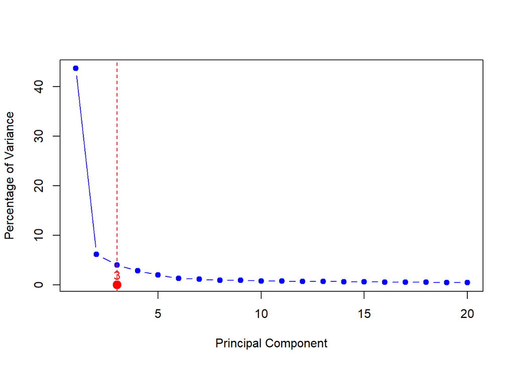

```r
plot_data <- data.frame(
  Variance = variance_ratios[1:20]*100,
  a = 1:20
)

plot(plot_data$a, plot_data$Variance,
     type = "b",
     xlab = "Principal Component",
     ylab = "Percentage of Variance",
     pch = 19, col ="blue")

elbow_point <- find_elbow(plot_data$a, plot_data$Variance)
abline(v = elbow_point, col ="red",lty =2)
points(elbow_point, variance_ratios[elbow_point], col="red",pch=19,cex=1.5)
text(elbow_point, variance_ratios[elbow_point]+2,elbow_point,col ="red")
```

**Explanation box (do not delete this section):**

```
# Q8_EXPLANATION
Explain your code here, and very briefly explain what the 'elbow' represents.

Obtaining the variance ratio:
pca_result$sdev^2: Get the variance.
Divide by the total variance to get the variance ratio for each.

Use plot() to create a line plot showing the percentage of each variance.

Identifying and marking inflection points:
Use the find_elbow() function to determine the location of 'elbow'.
Mark the 'elbow' locations with vertical lines and dots.

"pch = 19"means use solid circle
"cex = 1.5"means bigger size
"lty =2 " means dotted line

'elbow'means:This indicates a significant difference before and after a specific point.In the financial or stock market, this may indicate the presence of risk.
```

## Q9 : Cumulative variance

**Tasks:**  
(a) Calculate the cumulative variance ratios using `cumsum()` on the list of explained variance ratios from Q8.  
(b) Plot all these cumulative variance ratios (x-axis = principal component, y-axis = cumulative variance ratio).  
(c) Mark on your plot the principal component for which the cumulative variance ratio is greater than or equal to 95%.  
**Hints:** you could use `cumsum()` on your explained variance ratio vector to calculate the cumulative variance. This will return a numeric vector, where each value represents the total variance explained up to that principal component. To find where the cumulative variance first exceeds 95%, you might compare the cumulative vector with 0.95 and identify the first index where this condition holds true.

To visualize the cumulative variance, consider `plot()` or `plot(cumulative_vector, type = "l")` to create the plot. To highlight the principal component where the cumulative variance exceeds 95%, you could add a point or vertical line using `points()` or `abline(v = ...)` to mark the location.

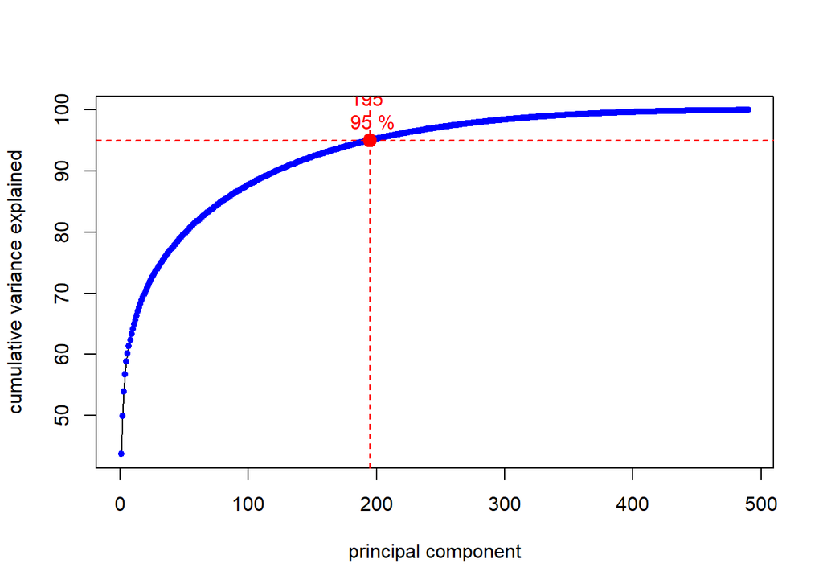

```r
# YOUR CODE GOES HERE
cumulative_variance <- cumsum(variance_ratios)

plot(cumulative_variance*100,
     type ="l",
     xlab ="principal component",
     ylab ="cumulative variance explained")

points(cumulative_variance*100,pch=19,col="blue",cex=0.7)

exceeds_95 <- which(cumulative_variance >= 0.95)[1]
abline(v = exceeds_95, col="red", lty=2)
abline(h =95, col ="red", lty =2)
points(exceeds_95, cumulative_variance[exceeds_95]*100,col ="red", pch=19, cex=1.5)
text(exceeds_95,cumulative_variance[exceeds_95]*100+5, paste(exceeds_95,"\n",round(cumulative_variance[exceeds_95]*100,1),"%"),col="red")
```

```r
print(paste(exceeds_95))
```

```
## [1] "195"
```

**Explanation box (do not delete this section):**

```
# Q9_EXPLANATION
Explain your code here.
Calculate cumulative variance:
cumsum(variance_ratios): Calculates the cumulative sum of variances, the result is a vector

Plot the cumulative variance plot:
type = "l": Creates a line plot, adding points to make the chart clearer
The Y-axis represents the percentage of cumulative explained variance
Mark the 95% threshold point:
which(cumulative_variance >= 0.95)[1]: Finds the first point that reaches or exceeds 95%
Add vertical and horizontal reference lines and then mark the position with a red dot
```

## Q10 : Standardised returns

**Tasks:**  
(a) **Standardise** your returns data frame from Q6 so that each ticker column has *zero mean* and *unit variance*. (Do not include the `Date` column.)  
(b) Repeat Q7 for this new standardised returns matrix.  
(c) Repeat Q8 for this standardised PCA.  
(d) Repeat Q9 for this standardised PCA.  
(e) In the Explanation box, **explain why standardising the returns before PCA can be useful** and how it affects the interpretation of the principal components.

**Hints:** `scale()` may be useful here.  
Standardising removes differences in volatility between tickers so that PCA focuses on their *correlation structure* rather than raw variance.

```r
# YOUR CODE GOES HERE
standardised_returns_matrix <- scale(returns_matrix)

PCA_standardised <- prcomp(standardised_returns_matrix)
loadings_standardised <- PCA_standardised$rotation
print(loadings_standardised[, 1:5])
```

```
##               PC1           PC2           PC3           PC4           PC5
## A     -0.04721487 -5.893595e-02  4.771380e-02 -4.287662e-02  0.0021180235
## AAPL  -0.04291645 -6.277619e-02  5.759062e-02 -4.973237e-02  0.0048951619
## ABBV  -0.03819902 -2.346537e-02 -1.619209e-02  4.098237e-02 -0.0647168707
## ABT   -0.03810434 -9.078752e-02 -3.395680e-03 -2.374242e-02  0.0048951561
## ACGL  -0.05032610  1.830690e-02 -6.025129e-02 -9.186326e-03  0.0559600113
## ACN   -0.05538764 -4.086793e-02  2.113739e-02 -1.672259e-02  0.0016438906
## ADBE  -0.03886382 -5.547261e-02  1.039716e-01  4.363642e-03 -0.0183459284
## ADI   -0.05063355 -3.467683e-03  6.998875e-02 -4.974025e-02  0.0185023070
## ADM   -0.04579834  1.685198e-02 -5.728256e-02 -5.080425e-02 -0.0730557427
## ADP   -0.05223353 -2.182560e-02 -5.177912e-03  4.390445e-02  0.0014934175
## ADSK  -0.04517819 -2.531942e-02  8.525475e-02 -1.014416e-02 -0.0078300330
## AEE   -0.03982367 -7.877015e-02 -9.706913e-02  1.636894e-02  0.0475307872
## AEP   -0.03790811 -6.873315e-02 -9.569969e-02  3.760576e-02  0.0225799935
## AES   -0.04731183  3.712195e-02  2.271713e-02  6.315102e-02 -0.0293770185
## AFL   -0.05698641  5.186804e-02 -3.051751e-02  4.012478e-02  0.0047816052
## AIG   -0.05628375  6.736837e-02 -1.920865e-02  1.971908e-02 -0.0059803929
## AIZ   -0.04559449  3.129479e-02 -2.810679e-02  5.126200e-03 -0.0121211291
## AJG   -0.05441067 -1.645722e-02 -5.391182e-03  5.313320e-02 -0.0300185778
## AKAM  -0.02958858 -8.082438e-02  2.540403e-02 -3.757230e-02 -0.0474308856
## ALB   -0.04435647  1.079248e-02  1.413435e-02 -9.567885e-02  0.0262164759
## ALGN  -0.04233068 -5.141354e-03  5.845455e-02  1.290747e-02  0.0372689551
## ALL   -0.04675239  7.902104e-03 -3.493469e-02  6.131821e-02 -0.0716556922
## ALLE  -0.05236619 -8.867310e-03 -1.732983e-02 -4.350818e-04  0.0132953975
## AMAT  -0.04940992 -7.975638e-03  7.844204e-02 -6.089635e-02  0.0186605663
## AMCR  -0.04812882  9.481488e-03 -1.385054e-02  4.387987e-03 -0.0176246161
## AMD   -0.03699627 -4.054965e-02  9.624821e-02 -4.368283e-02 -0.0056290950
## AME   -0.06028552  5.998541e-03  4.399750e-03  2.629612e-03 -0.0139014927
## AMGN  -0.03142176 -6.639017e-02 -3.626025e-02 -3.116600e-02 -0.0506895608
## AMP   -0.05936648  3.217793e-02 -1.119668e-02 -4.726932e-02  0.0368572219
## AMT   -0.04094380 -8.589710e-02 -3.192516e-02  3.497640e-02  0.0267901665
## AMZN  -0.03163323 -6.001633e-02  8.448706e-02 -5.195995e-02 -0.0048216993
## ANET  -0.04122014 -3.358326e-02  4.514274e-02 -5.900023e-02  0.0076032460
## ANSS  -0.03860629 -6.018340e-02  6.544575e-02 -4.421904e-02  0.0163405202
## AON   -0.04849899 -1.749561e-02 -4.929477e-03  1.780896e-02 -0.0335187552
## AOS   -0.04361120  2.117622e-03 -4.883545e-05 -4.166354e-02  0.0481237627
## APA   -0.04105562  7.350211e-02  9.506990e-04 -3.181381e-02 -0.1067487991
## APD   -0.04841430 -2.759168e-02 -2.110422e-02 -4.109792e-02  0.0103091526
## APH   -0.05865044  1.796023e-03  3.396174e-02 -2.398629e-02  0.0073750077
## APTV  -0.04860891  5.990750e-02  6.597428e-02  5.921257e-02 -0.0118581605
```

[output cut: 436 more lines]

```
## WM    -0.04477202 -5.718913e-02 -5.899211e-02  6.710733e-04 -0.0428298854
## WMB   -0.04200048  7.283354e-02  1.099721e-02  5.201557e-02 -0.1492864009
## WMT   -0.02431911 -7.441874e-02 -2.119842e-02 -6.308770e-02 -0.0527826488
## WRB   -0.05070780  1.340967e-02 -7.218671e-02 -1.725349e-02  0.0276093383
## WST   -0.03133846 -7.694622e-02  6.112090e-02 -1.108379e-02 -0.0071579338
## WTW   -0.04705969 -1.337422e-02 -5.169179e-03  2.960183e-02 -0.0157610287
## WY    -0.05273571  7.385042e-03 -1.938235e-02 -1.595271e-02  0.0520584988
## WYNN  -0.04541835  7.628105e-02  5.282166e-02  2.977525e-02  0.0140937414
## XEL   -0.03931580 -8.036235e-02 -8.484602e-02  4.833873e-02  0.0342095689
## XOM   -0.04549409  5.964385e-02 -4.205602e-02 -5.853103e-02 -0.1197656967
## XYL   -0.05298738 -4.424803e-03 -9.389716e-03 -4.501071e-02  0.0490385463
## YUM   -0.05306526  2.415526e-03  8.828675e-03  5.064086e-02  0.0658645312
## ZBH   -0.05032292  1.856830e-02  4.444021e-03  3.946162e-02 -0.0053011826
## ZBRA  -0.04976909 -1.900993e-02  4.034065e-02 -6.441288e-02  0.0114689849
## ZTS   -0.04953298 -5.791755e-02  3.497978e-02  4.746672e-02 -0.0056503248
```

```r
variance_ratios_standardised <- PCA_standardised$sdev^2/sum(PCA_standardised$sdev^2)

first_variance_standardised <- variance_ratios_standardised[1]*100
print(paste(round(first_variance_standardised,2),"%"))
```

```
## [1] "42.42 %"
```

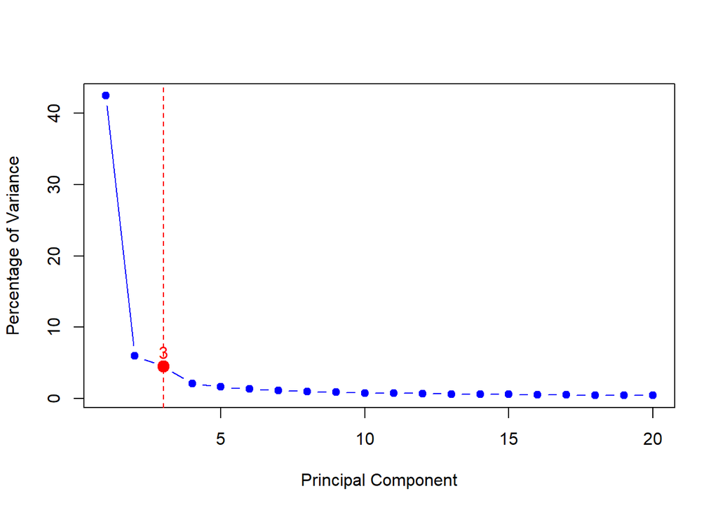

```r
plot_data_standardised <- data.frame(
  Variance = variance_ratios_standardised[1:20]*100,
  a = 1:20
)
plot(plot_data_standardised$a, plot_data_standardised$Variance,type ="b", xlab="Principal Component", ylab ="Percentage of Variance", pch=19, col = "blue")

elbow_point_standardised <- find_elbow(plot_data_standardised$a, plot_data_standardised$Variance)

abline(v = elbow_point_standardised,col ="red",lty=2)
points(elbow_point_standardised,plot_data_standardised$Variance[elbow_point_standardised], col ="red",pch = 19, cex= 1.5)
text(elbow_point_standardised,plot_data_standardised$Variance[elbow_point_standardised]+2,elbow_point_standardised, col ="red")
```

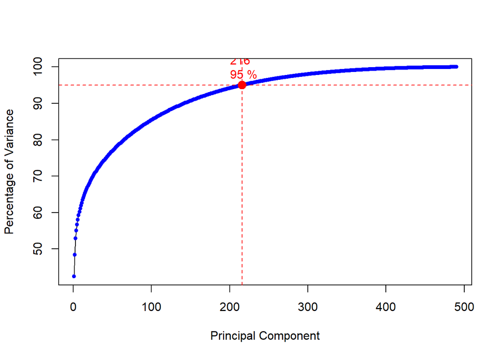

```r
cumulative_variance_standardised <- cumsum(variance_ratios_standardised)

plot(cumulative_variance_standardised*100, type ="l",xlab="Principal Component", ylab ="Percentage of Variance")

points(cumulative_variance_standardised *100, pch =19, col="blue",cex=0.7)
exceeds_95_standardised <- which(cumulative_variance_standardised >= 0.95)[1]
abline(v = exceeds_95_standardised, col="red", lty=2)
abline(h =95, col ="red", lty =2)
points(exceeds_95_standardised, cumulative_variance_standardised[exceeds_95_standardised]*100,col ="red", pch=19, cex=1.5)
text(exceeds_95_standardised,cumulative_variance_standardised[exceeds_95_standardised]*100+5, paste(exceeds_95_standardised,"\n",round(cumulative_variance_standardised[exceeds_95_standardised]*100,1),"%"),col="red")
```

```r
print(paste(exceeds_95_standardised))
```

```
## [1] "216"
```

**Explanation box (do not delete this section):**

```
# Q10_EXPLANATION
Explain why standardising before PCA is useful, and how it changes the PCA results.
Standardized PCA can reduce the impact of some samples with significant changes. This ensures that the influence of each sample on the results will not be focused.
```

## Q11 : COMP529 Research Problem Question

**Task:**  
Financial datasets often come from multiple providers, and the same company may appear under different names or identifiers (e.g. “Google”, “Alphabet”, “GOOG”, “GOOGL”).  
This challenge - known as **entity alignment** - was introduced in Week 8 of the lectures and is an active research problem in Big Data.

Write **250–300 words** explaining:

1. **What entity alignment is**, and why it is difficult in large, heterogeneous datasets.
2. **Why misaligned or duplicated entities can distort PCA-based market analysis**, especially when constructing price panels or computing covariance matrices.
3. **One recent peer-reviewed paper** that proposes a solution to the entity-alignment problem (e.g., using embeddings, graph methods, or LLM-based techniques).
4. A short description of **how improved entity alignment would lead to more reliable PCA results** in practical financial analytics.

You only need **one** reference. Focus on clarity and explanation.  
**Hint:** If you are unsure where to start, try searching **Google Scholar** for terms like *entity alignment*, *entity matching*, *record linkage*, or *knowledge graph alignment*. Choose any one paper that explains a method (for example, using embeddings, graph neural networks, or transformer models). You do not need to understand every mathematical detail - aim to explain the main idea in your own words and why it helps match entities correctly in large datasets.

**Explanation box:**

```
# Q11_EXPLANATION
Write your approx 250–300 word discussion here, including at least one reference.
The task of entity alignment is to identify entities that point to the same real-world object but are located in different knowledge graphs.

I read the examples in the reference and also learned about the process of entity alignment. First of all, to achieve "entity alignment", a knowledge graph is required, and a knowledge graph consists of multiple sets (Zeng,W. et al.(2021)). Entity collection, this is a relatively detailed collection, and its content can be specific place names, building names or subject names. The second required set is the relation set, which refers to the possible relations that may exist in the entity set. For instance, if a certain building is located in a specific place name, this relationship is the content of the relationship set. The third required set is the triple set. This refers to the combination of entities and relationships that have long been established as facts. When we perform "entity alignment", we need multiple knowledge graphs, such as those in different languages. "Seeds" are also needed. The meaning of "seeds" is the training data or the result of successful "entity alignment".My understanding is that "entity alignment" is to filter the same target among different data. This enables us to understand the same existing reality from different directions.

Reference：
Zeng, W. et al. (2021) ‘Reinforcement Learning–based Collective Entity Alignment with Adaptive Features’, ACM transactions on information systems, 39(3), pp. 1–31. Available at: https://doi.org/10.1145/3446428.
```